# Kaggle House Prices

### Pre-processing the Data

From the data descriptions, NA is used as a legitimate value in many factor columns to indicate the lack of a feature, such as a pool.

Let’s find any Factor columns that contain NAs, so we can convert the NAs to their own factor:

```r
#First Find Factor Cols and standardise N/As
trainingfct = training %>% select_if(is.factor) %>% lapply(addNA) %>% replace(.,is.na(.),"")
testingfct = testing %>% select_if(is.factor) %>% lapply(addNA) %>% replace(.,is.na(.),"")

#Convert NAs in Factor Variables to factor variables
trainingfct = lapply(trainingfct, addNA)
testingfct = lapply(testingfct, addNA)

#Recombine Dataset by adding the changed columns of the fct dataframes with the
#unchanged columns of the original dataframes
train2 = training[, -which(names(training) %in% names(trainingfct))]
test2 = testing[, -which(names(testing) %in% names(testingfct))]
newtraining = cbind(train2, trainingfct)
newtesting = cbind(test2, testingfct)
```

To demonstrate that this has worked, let’s compare a factor variable that has been modified. Firstly we need to see which ones they were:

```r
summary(trainingfct)
```

```
##               Length Class  Mode
## MSZoning      1460   factor numeric
## Street        1460   factor numeric
## Alley         1460   factor numeric
## LotShape      1460   factor numeric
## LandContour   1460   factor numeric
## Utilities     1460   factor numeric
## LotConfig     1460   factor numeric
## LandSlope     1460   factor numeric
## Neighborhood  1460   factor numeric
## Condition1    1460   factor numeric
## Condition2    1460   factor numeric
## BldgType      1460   factor numeric
## HouseStyle    1460   factor numeric
## RoofStyle     1460   factor numeric
## RoofMatl      1460   factor numeric
## Exterior1st   1460   factor numeric
## Exterior2nd   1460   factor numeric
## MasVnrType    1460   factor numeric
## ExterQual     1460   factor numeric
## ExterCond     1460   factor numeric
## Foundation    1460   factor numeric
## BsmtQual      1460   factor numeric
## BsmtCond      1460   factor numeric
## BsmtExposure  1460   factor numeric
## BsmtFinType1  1460   factor numeric
## BsmtFinType2  1460   factor numeric
## Heating       1460   factor numeric
## HeatingQC     1460   factor numeric
## CentralAir    1460   factor numeric
## Electrical    1460   factor numeric
## KitchenQual   1460   factor numeric
## Functional    1460   factor numeric
## FireplaceQu   1460   factor numeric
## GarageType    1460   factor numeric
## GarageFinish  1460   factor numeric
## GarageQual    1460   factor numeric
## GarageCond    1460   factor numeric
## PavedDrive    1460   factor numeric
## PoolQC        1460   factor numeric
## Fence         1460   factor numeric
## MiscFeature   1460   factor numeric
## SaleType      1460   factor numeric
## SaleCondition 1460   factor numeric
```

Let’s look at PoolQC for both the original and processed datasets, as we noted before there were several NA values in it (which makes sense if N/A is used to indicate ‘not present’, as many houses do not have pools)

```r
head(training$PoolQC)
```

```
## [1] <NA> <NA> <NA> <NA> <NA> <NA>
## Levels: Ex Fa Gd
```

```r
head(newtraining$PoolQC)
```

```
## [1] <NA> <NA> <NA> <NA> <NA> <NA>
## Levels: Ex Fa Gd <NA>
```

```r
head(testing$PoolQC)
```

```
## [1] <NA> <NA> <NA> <NA> <NA> <NA>
## Levels: Ex Gd
```

```r
head(newtesting$PoolQC)
```

```
## [1] <NA> <NA> <NA> <NA> <NA> <NA>
## Levels: Ex Gd <NA>
```

We can see that the newtraining table has an additional level ‘NA’ that did not previously exist.

We need to convert the factor variables into a numerical format before we feed them into a predictive model. Here they are converted into a one-hot arrangement:

```r
#Turn Factors into One-Hot
dmy = dummyVars("~ .", data = newtraining)
factored_train = data.frame(predict(dmy, newdata = newtraining))
dmy = dummyVars("~ .", data = newtesting)
factored_test = data.frame(predict(dmy, newdata = newtesting))

dim(factored_train)
```

```
## [1] 1460  333
```

```r
dim(factored_test)
```

```
## [1] 1459  314
```

We can see that, in converting to a one-hot arrangement, we have produced columns in each set that are not in both sets, because some factors did not exist in each dataset. As there is no point training on data that doesn’t exist in the prediction dataset, let’s remove columns that don’t exist in both sets.

```r
head(factored_train[,"SalePrice"])
```

```
## [1] 208500 181500 223500 140000 250000 143000
```

```r
#Save SalePrices so we can put them back later.
SalePrices = factored_train[,"SalePrice"]
dim(factored_train)
```

```
## [1] 1460  333
```

```r
factored_train = factored_train[,colnames(factored_train)%in%names(factored_test)]
dim(factored_train)
```

```
## [1] 1460  314
```

```r
factored_test = factored_test[,colnames(factored_test)%in%names(factored_train)]
dim(factored_test)
```

```
## [1] 1459  314
```

```r
#Put SalePrices back in
factored_train["SalePrice"]=SalePrices
dim(factored_train)
```

```
## [1] 1460  315
```

Perfect, they are the correct length. The training set became one column larger when we added the sale prices back in.

While we’ve converted the NA’s in factor variables into their own factors, there still exist some NA’s in the continuous variables. Let’s see how many rows still contain NA’s:

```r
dim(factored_train[complete.cases(factored_train),])
```

```
## [1] 1121  315
```

```r
dim(factored_train)
```

```
## [1] 1460  315
```

```r
dim(factored_test[complete.cases(factored_test),])
```

```
## [1] 1146  314
```

```r
dim(factored_test)
```

```
## [1] 1459  314
```

We can see that 1121 of 1460 rows in the training set are complete. We could discard the incomplete rows, but that is a large portion of our dataset to ignore. Let’s impute all non-factor NA values.A similar fraction of the test set are also incomplete.

```r
#Remove Saleprice from training set - we won't preprocess it
factored_train_without_saleprice = factored_train %>% select(-"SalePrice")
#Create preprocesing object and run it on training set
preObj <- preProcess(factored_train_without_saleprice, method=c('scale','center','knnImpute'))
```

```
## Warning in preProcess.default(factored_train_without_saleprice, method =
## c("scale", : These variables have zero variances: MSZoning.NA, Street.NA,
## LotShape.NA, LandContour.NA, Utilities.NA, LotConfig.NA, LandSlope.NA,
## Neighborhood.NA, Condition1.NA, Condition2.NA, BldgType.NA, HouseStyle.NA,
## RoofStyle.NA, RoofMatl.NA, Exterior1st.NA, Exterior2nd.NA, ExterQual.NA,
## ExterCond.NA, Foundation.NA, Heating.NA, HeatingQC.NA, CentralAir.NA,
## KitchenQual.NA, Functional.NA, PavedDrive.NA, SaleType.NA, SaleCondition.NA
```

```r
train_processed = predict(preObj,factored_train_without_saleprice)
test_processed = predict(preObj, factored_test)
#Add back Saleprice to training set
train_processed["SalePrice"]=factored_train["SalePrice"]
```

Note the zero variance warning above. When converting to one-hot format, we’ve probably created some variables containing zero or very little useful data. Let’s have a look:

```r
nearZeroVarColumns = nearZeroVar(train_processed)
length(nearZeroVarColumns)
```

```
## [1] 187
```

Quite a few. Let’s delete them - They add little information to the model and will, at best, slow down training and may reduce the performance of the model.

```r
dim(train_processed)
```

```
## [1] 1460  315
```

```r
train_processed = train_processed[,-nearZeroVarColumns]
test_processed = test_processed[,-nearZeroVarColumns]
dim(train_processed)
```

```
## [1] 1460  128
```

```r
dim(test_processed)
```

```
## [1] 1459  127
```

Let’s split the dataset into a training set and a validation set:

```r
set.seed(5)
inTrain = createDataPartition(train_processed$SalePrice, p=0.7,list=FALSE)
train_set = train_processed[inTrain,]
val_set = train_processed[-inTrain,]
```

### Training Regression Models

The processed data is used to train a variety of popular regression models, using the caret package. Each model is trained using a random hyperparameter search, which selects the best model through a cross-validation method, or in the case of the linear regression model, using the recursive feature elimination method to select the optimal features to use. All models are trained only using the training set data.

Each model is then used to predict the SalePrice figures for the test set, and the RMSLE (the metric used by the Kaggle competition for model ranking) for each stored in a dataframe for later comparison.

Linear Regression:

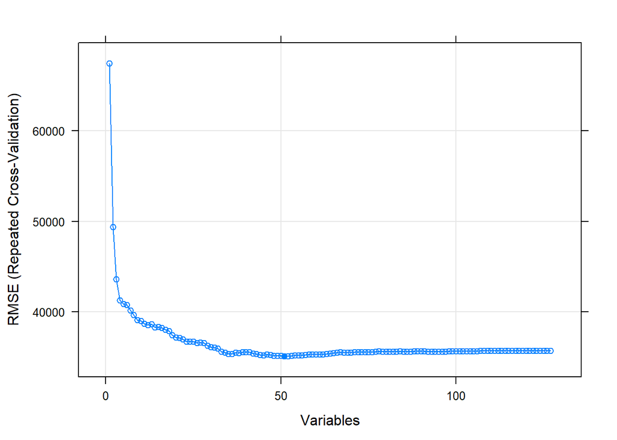

```r
# define the control using a linear model selection function
control <- rfeControl(functions=lmFuncs, method="repeatedcv", number=10, repeats=3)
# run the RFE algorithm
model.rfe.lm <- rfe(x=train_set[,-which(names(train_set) == "SalePrice")], y=train_set[,"SalePrice"], sizes=seq(1,127, by=1), rfeControl=control)
# plot the results
plot(model.rfe.lm, type=c("g", "o"))
```

```r
#Test performance on the dev set and save RMSLE value in a dataframe.
predictions.rfe.lm <- predict(model.rfe.lm, val_set)
models = data.frame('Model'='rfe.lm', 'RMSLE'=RMSLE(predictions.rfe.lm, val_set$SalePrice))
```

SVM:

```r
fitControl <- trainControl(method = "adaptive_cv",
                           number = 5,
                           search="random",
                           adaptive = list(min = 3, alpha = 0.05,
                                             method = "gls", complete = TRUE))

model.svm <- train(SalePrice ~ ., train_set, method='svmLinear',
                         metric="RMSE",
                         trControl=fitControl,
                         tuneLength=25,
                         verbose=FALSE)

#Print training performance of various hyperparameter combinations.
model.svm$results %>%
  dplyr::arrange(RMSE) %>%
  head(6)
```

```
##              C     RMSE  Rsquared      MAE    RMSESD RsquaredSD     MAESD
## 1 107.71809024 30682.57 0.8521415 18164.20  7176.512 0.07156421 1051.6917
## 2  48.14293520 30820.98 0.8515868 18393.11  6500.003 0.06322107  735.0193
## 3 417.13085708 33222.17 0.8297644 19512.37  7429.527 0.06938913 1308.9692
## 4 212.79727091 33291.36 0.8297917 19130.85  7370.954 0.07213679 1260.3978
## 5  45.76199414 33366.21 0.8246971 19170.42  8000.737 0.07642824 1033.3326
## 6   0.09044859 33682.26 0.8102163 17421.25 10052.507 0.12201941 1065.6699
##   .B
## 1  4
## 2  4
## 3  3
## 4  3
## 5  3
## 6  5
```

```r
#Test performance on the validation set
predictions.svm <- predict(model.svm, val_set)
models = rbind(models, data.frame('Model'='svm', 'RMSLE'=RMSLE(predictions.svm, val_set$SalePrice)))
```

Cubist:

```r
fitControl <- trainControl(method = "adaptive_cv",
                           number = 5,
                           search="random",
                           adaptive = list(min = 4, alpha = 0.05,
                                             method = "gls", complete = TRUE))
# tune the model
model.cubist <- train(SalePrice ~ .,train_set, method='cubist',
                   metric= "RMSE",
                   trControl=fitControl,
                   tuneLength=25,
                   verbose=FALSE)

#Print training performance of various hyperparameter combinations.
model.cubist$results %>%
  dplyr::arrange(RMSE) %>%
  head(6)
```

```
##   committees neighbors     RMSE  Rsquared      MAE   RMSESD RsquaredSD
## 1         91         8 38240.70 0.7885552 17133.92 24242.16  0.2038255
## 2         64         7 38298.21 0.7881086 17212.98 24252.89  0.2037391
## 3         75         9 38313.53 0.7879949 17159.54 24531.75  0.2060238
## 4         48         9 38451.62 0.7860133 17208.37 24180.36  0.2026491
## 5         19         9 38615.42 0.7842675 17330.42 23596.76  0.1991476
## 6         41         9 38762.80 0.7837556 17288.16 24330.84  0.2030619
##      MAESD .B
## 1 3349.201  5
## 2 3385.560  5
## 3 3472.864  5
## 4 3468.351  5
## 5 3470.465  5
## 6 3517.682  5
```

```r
#Test performance on the dev set
predictions.cubist <- predict(model.cubist, val_set)
models = rbind(models, data.frame('Model'='cubist', 'RMSLE'=RMSLE(predictions.cubist, val_set$SalePrice)))
```

Random_forest:

```r
fitControl <- trainControl(method = "adaptive_cv",
                           number = 4,
                           search="random",
                           adaptive = list(min = 3, alpha = 0.05,
                                             method = "gls", complete = TRUE))

# tune the model
model.rf <- train(SalePrice ~ .,train_set, method='rf',
                   metric= "RMSE",
                   trControl=fitControl,
                   tuneLength=25,
                   verbose=FALSE)

#Print training performance of various hyperparameter combinations.
model.rf$results %>%
  dplyr::arrange(RMSE) %>%
  head(6)
```

```
##   mtry     RMSE  Rsquared      MAE   RMSESD RsquaredSD    MAESD .B
## 1   34 32860.52 0.8375769 18158.81 8521.921 0.06618763 1745.887  4
## 2   39 32954.06 0.8374730 18166.96 8497.822 0.06439542 1684.885  4
## 3   43 32993.66 0.8361031 18077.14 8471.453 0.06527926 1727.222  4
## 4   63 33017.53 0.8356742 18247.53 8448.305 0.06447432 1730.214  4
## 5   13 33103.29 0.8397039 18452.08 9173.655 0.06405756 1888.324  4
## 6   51 33118.01 0.8351297 18199.02 8422.787 0.06396933 1682.454  4
```

```r
#Test performance on the validation set
predictions.rf <- predict(model.rf, val_set)
models = rbind(models, data.frame('Model'='random forest', 'RMSLE'=RMSLE(predictions.rf, val_set$SalePrice)))
```

Gradient boosting:

```r
fitControl <- trainControl(method = "adaptive_cv",
                           number = 5,
                           search="random",
                           adaptive = list(min = 4, alpha = 0.05,
                                             method = "gls", complete = TRUE))

model.gbm <- train(SalePrice ~ ., train_set, method='gbm',
                         metric="RMSE",
                         trControl=fitControl,
                         tuneLength=30,
                         verbose=FALSE)

#Print training performance of various hyperparameter combinations.
model.gbm$results %>%
  dplyr::arrange(RMSE) %>%
  head(6)
```

```
##     shrinkage interaction.depth n.minobsinnode n.trees     RMSE  Rsquared
## 1 0.202879815                 5             12    3244 30217.22 0.8553441
## 2 0.005319389                10              8     431 30371.90 0.8763382
## 3 0.018343235                 7             14     869 30971.26 0.8448820
## 4 0.165195448                 7             13    3580 31215.59 0.8497908
## 5 0.211611969                 4             20    1252 31369.20 0.8531648
## 6 0.218784000                 2              5      27 31508.57 0.8416917
##        MAE    RMSESD RsquaredSD     MAESD .B
## 1 19562.07  3911.052 0.02881579  846.1184  4
## 2 18696.57  6507.618 0.03122644 1652.1065  4
## 3 16880.80 10433.697 0.09276751 2067.8728  5
## 4 18912.56  5006.413 0.03330048 1333.3015  4
## 5 19705.11  4434.724 0.01957255 1802.1135  4
## 6 21072.56  4381.388 0.02921883  357.6996  4
```

```r
#Test performance on the validation set
predictions.gbm<- predict(model.gbm, val_set)
models = rbind(models, data.frame('Model'='gbm', 'RMSLE'=RMSLE(predictions.gbm, val_set$SalePrice)))
```

K Nearest Neighbours:

```r
fitControl <- trainControl(method = "adaptive_cv",
                           number = 5,
                           search="random",
                           adaptive = list(min = 3, alpha = 0.05,
                                             method = "gls", complete = TRUE))

model.knn <- train(SalePrice ~ ., train_set, method='kknn',
                         metric="RMSE",
                         trControl=fitControl,
                         tuneLength=25,
                         verbose=FALSE)

#Print training performance of various hyperparameter combinations.
model.knn$results %>%
  dplyr::arrange(RMSE) %>%
  head(6)
```

```
##   kmax  distance       kernel     RMSE  Rsquared      MAE   RMSESD
## 1  171 0.2944470    triweight 34425.33 0.7884951 21297.88 2486.427
## 2   64 0.7397157 epanechnikov 34500.46 0.7881820 21422.29 2794.852
## 3   92 0.5150876          cos 34534.97 0.7865135 21491.29 2742.669
## 4  310 1.3732736          inv 35258.13 0.7842767 21605.02 3256.619
## 5  174 1.7434163          cos 35334.07 0.7807366 21601.64 4306.427
## 6   67 1.1573530     gaussian 35395.64 0.7810711 21268.69 3605.984
##   RsquaredSD     MAESD .B
## 1 0.03021067  946.3672  4
## 2 0.03831335  979.7199  4
## 3 0.03351105 1266.6034  4
## 4 0.04937497 1173.0698  3
## 5 0.06897954 1852.7181  3
## 6 0.05101607 1363.6348  3
```

```r
#Test performance on the validation set
predictions.knn <- predict(model.knn, val_set)
models = rbind(models, data.frame('Model'='knn', 'RMSLE'=RMSLE(predictions.knn, val_set$SalePrice)))
```

### Reviewing the models

```r
models[order(models$RMSLE),]
```

```
##           Model     RMSLE
## 5           gbm 0.1237887
## 3        cubist 0.1255331
## 2           svm 0.1332077
## 4 random forest 0.1430720
## 6           knn 0.1629795
## 1        rfe.lm 0.1675283
```

We can see the SVM, cubist, gradient boosting and random forest models provided the greatest performance. Some models improved a little with the hyperparameter tuning, others saw no improvement.

### Ensemble Model

Let’s see if our performance improves if we ensemble the 4 best models (svm, cubist, gbm and rf):

```r
#Prepare ensemble training data
#trainingpredictions.rfe.lm = predict(model.rfe.lm, newdata = train_processed)
trainingpredictions.randomforest = predict(model.rf, newdata = train_set)
trainingpredictions.cubist = predict(model.cubist, newdata = train_set)
trainingpredictions.svm = predict(model.svm, newdata = train_set)
trainingpredictions.gbm = predict(model.gbm, newdata = train_set)

ensembleTrainingData = data.frame("cubist"=trainingpredictions.cubist,"rf"=trainingpredictions.randomforest, "gbm"=trainingpredictions.gbm, "svm"=trainingpredictions.svm, "SalePrice"=train_set$SalePrice)

# make a grid of values to test
fitControl <- trainControl(method = "adaptive_cv",
                           number = 5,
                           search="random",
                           adaptive = list(min = 2, alpha = 0.05,
                                             method = "gls", complete = TRUE))

# tune the model
model.ensemble <- train(x=ensembleTrainingData[,-which(names(ensembleTrainingData) == "SalePrice")],    y=ensembleTrainingData[,"SalePrice"], method='gbm',
                   metric= "RMSE",
                   trControl=fitControl,
                   tuneLength=25,
                   verbose=FALSE)

model.ensemble$results %>%
  dplyr::arrange(RMSE) %>%
  head(6)
```

```
##    shrinkage interaction.depth n.minobsinnode n.trees     RMSE  Rsquared
## 1 0.05905023                 1             17     643 11062.54 0.9769578
## 2 0.03204869                 3              8    4539 11649.92 0.9784437
## 3 0.10086006                 7              8    4558 12073.35 0.9777126
## 4 0.09188637                10              8    4174 12449.44 0.9760374
## 5 0.04976639                 5              9    3038 12474.69 0.9752320
## 6 0.20769040                10             16    1493 12714.67 0.9718184
##        MAE   RMSESD RsquaredSD     MAESD .B
## 1 5415.173 3308.245 0.01217997  408.2195  3
## 2 4948.179 5338.712 0.01425123 1077.4043  5
## 3 5388.693 5013.232 0.01176652  939.3519  5
## 4 5491.164 5027.420 0.01283002  993.2396  5
## 5 5337.721 5305.888 0.01564574 1011.8114  5
## 6 5948.711 3631.716 0.01615879  620.7046  2
```

```r
#Prepare ensemble validation data
#trainingpredictions.rfe.lm = predict(model.rfe.lm, newdata = train_processed)
validationpredictions.randomforest = predict(model.rf, newdata = val_set)
validationpredictions.cubist = predict(model.cubist, newdata = val_set)
validationpredictions.svm = predict(model.svm, newdata = val_set)
validationpredictions.gbm = predict(model.gbm, newdata = val_set)

ensembleValidationData = data.frame("cubist"=validationpredictions.cubist,"rf"=validationpredictions.randomforest, "gbm"=validationpredictions.gbm, "svm"=validationpredictions.svm, "SalePrice"=val_set$SalePrice)

#Test against the validation set:
predictions.ensemble <- predict(model.ensemble, ensembleValidationData)

RMSLE(predictions.ensemble, val_set$SalePrice)
```

```
## [1] 0.1296565
```

```r
#Add performance to dataframe
models = rbind(models, data.frame('Model'='ensemble', 'RMSLE'=RMSLE(predictions.ensemble, val_set$SalePrice)))
```

Let’s have a look at the performance of our models:

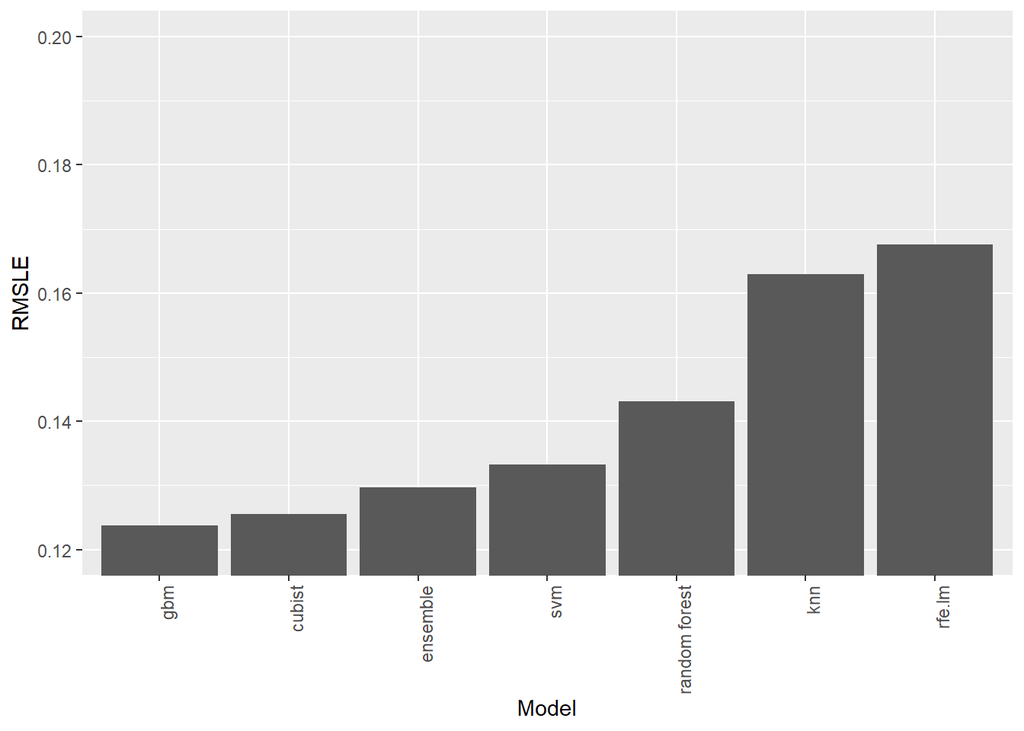

```r
plot = ggplot(models[order(models$RMSLE),], aes( reorder(Model, RMSLE), RMSLE))
plot = plot + geom_bar(stat='identity')+xlab('Model')
plot = plot + coord_cartesian(ylim=c(0.12,0.2))
plot = plot + theme(axis.text.x = element_text(angle = 90, hjust = 1))
plot
```

Our ensemble model provides no real improvement in performance. Consistently (over several runs) the gbm model provided the best performance.

### Preparing Submission

Let’s retrain the gbm model using the full training set, and then use it to make predictions on the test set.

```r
# make a grid of values to test
grid <- expand.grid(n.trees           = model.gbm$bestTune$n.trees,
                    shrinkage         = model.gbm$bestTune$shrinkage,
                    n.minobsinnode    = model.gbm$bestTune$n.minobsinnode,
                    interaction.depth = model.gbm$bestTune$interaction.depth)
fitControl <- trainControl(method = "repeatedcv",
                           number = 5, repeats=3)
# tune the model
model.gbm_fullset <- train(x=train_processed[,-which(names(train_processed) == "SalePrice")],                    y=train_processed[,"SalePrice"], method='gbm',
                   metric= "RMSE",
                   trControl=fitControl,
                   tuneGrid=grid,
                   verbose=FALSE)

#Print training performance of various hyperparameter combinations.
model.gbm_fullset$results %>%
  dplyr::arrange(RMSE) %>%
  head(6)
```

```
##   n.trees  shrinkage n.minobsinnode interaction.depth     RMSE  Rsquared
## 1     869 0.01834323             14                 7 28052.68 0.8756426
##        MAE   RMSESD RsquaredSD    MAESD
## 1 15835.36 6176.699 0.04993877 1299.705
```

Get test set predictions:

```r
#Get test set predictions

testpredictions.gbm_fullset = predict(model.gbm_fullset, test_processed)
```

Put the predictions into the appropriate format:

```r
submission_table=data.frame(Id=testing[,"Id"],SalePrice=testpredictions.gbm_fullset)

#Check it looks correct
head(submission_table)
```

```
##     Id SalePrice
## 1 1461  125715.3
## 2 1462  165064.3
## 3 1463  183459.2
## 4 1464  191426.7
## 5 1465  181509.9
## 6 1466  176652.7
```

Output the table to a csv file for submission:

```r
write.csv(submission_table, file = "submission.csv", row.names=FALSE)
```

### Conclusion and Summary

The submitted file had a RMSLE of 0.128, coming in at the 70th percentile of submissions at the time of submission. There is scope for improvement with trialling additional models, ensembling more models together, or from further feature engineering.